# Lake Powell: Preliminary data analysis

Tammy Lee

September 11, 2017

## Methods

### Site descriptions

The five sites used for this project include:

- Colorado River at Cisco (Cisco)
- San Juan at Bluff (Bluff)
- Green River at Green River (Green)
- Colorado River at Lees Ferry (Lees)
- Colorado River at Colorado River, near Grand Canyon (Colorado)

Cisco, Green, and Bluff represent boundary conditions for Lake Powell and are the three major tributaries to Lake Powell (Green and Colorado merge before entering Lake Powell but these sites have long term monitoring data available). Lees is approximately 25 km below the dam and measures reservoir outflow. Colorado is a site within Grand Canyon and provides an approximation of any biogeochemical processing that might be occurring within the river itself.

### Data collection and analysis

Among group comparisons for five specific parameters were assessed using Kruskal-Wallis for pre- and post-dam construction (total of ten comparisons). Parameters included were nitrate as nitrogen, calcium, magnesium, bicarbonate, and pH.

## Summary

A total of 33 parameters were initially examined across all five sites. Many paraments tended to exhibit strongly observable cyclical patterns prior to dam construction. Post-dam construction there appeared to be a lag response with an attenuated, less distinct cyclical pattern.

Of the 33 parameters, five were further examined for among group comparisons pre- and post-dam construction. For the most part nitrate concentrations were different across all sites pre- and post-dam construction. Magnesium and bicarbonate concentrations went from heterogenous across all sites pre-dam construction to more homogenous across most sites post-dam construction. Calcium concentrations went from some sites being similar to more sites being similar. pH was the only parameter that went from more similar across sites to more different across sites post-dam construction.

## Future directions

Although these preliminary results suggest parameter changes across sites might be due to dam construction, further analyses must be conducted and additional parameters investigated to fully attribute differences to dam construction.In addition, two of the stations are located below Lake Powell, and any changes upstream may be due to other factors not included in this preliminary analysis. The preliminary analyses of this project serve to provide a first pass of available data and help make future decisions about parameters and analyses on which to for this long-term data set. Current next steps include time-series analysis.

## Results

There were approximately 967 different parameters measured for Bluff, Colorado, Green, Lees, and Cisco combined. Of those 967, 33 were of interest based on availability of data across all sites. These 33 parameters were further cleaned to a total of 27 usable parameters (several parameters were combined with other parameters because measurement methods were changed at some point during the monitoring period). Table 1 provides the parameter code, the group it belongs to, and description.

Table 1. Code and description of parameters used in this analysis. Codes with a “c” designation were combined

| Parameter | Group | Description |
| --- | --- | --- |
| p00028 | Information | Agency analyzing sample, code |
| p82398 | Information | Sampling method, code |
| p00935 | Inorganics, Major, Metals | Potassium, water, filtered, milligrams per liter |
| p00915 | Inorganics, Major, Metals | Calcium, water, filtered, milligrams per liter |
| p00925 | Inorganics, Major, Metals | Magnesium, water, filtered, milligrams per liter |
| p00930 | Inorganics, Major, Metals | Sodium, water, filtered, milligrams per liter |
| p00940 | Inorganics, Major, Non-metals | Chloride, water, filtered, milligrams per liter |
| p00945 | Inorganics, Major, Non-metals | Sulfate, water, filtered, milligrams per liter |
| p00955 | Inorganics, Major, Non-metals | Silica, water, filtered, milligrams per liter as SiO2 |
| p00410c | Inorganics, Major, Non-metals | Acid neutralizing capacity, water, unfiltered, fixed endpoint (pH 4.5) titration, laboratory, milligrams per liter as calcium carbonate |
| p00191 | Inorganics, Major, Non-metals | Hydrogen ion, water, unfiltered, calculated, milligrams per liter |
| p00440c | Inorganics, Major, Non-metals | Bicarbonate, water, unfiltered, fixed endpoint (pH 4.5) titration, field, milligrams per liter |
| p00405 | Inorganics, Major, Non-metals | Carbon dioxide, water, unfiltered, milligrams per liter |
| p01046 | Inorganics, Minor, Metals | Iron, water, filtered, micrograms per liter |
| p71851 | Nutrient | Nitrate, water, filtered, milligrams per liter as nitrate |
| p71887 | Nutrient | Total nitrogen [nitrate + nitrite + ammonia + organic-N], water, unfiltered, milligrams per liter as nitrate |
| p00613c | Nutrient | Nitrate, water, filtered, milligrams per liter as nitrogen |
| p00660 | Nutrient | Orthophosphate, water, filtered, milligrams per liter as PO4 |
| p00671 | Nutrient | Orthophosphate, water, filtered, milligrams per liter as phosphorus |
| p70507 | Nutrient | Orthophosphate, water, unfiltered, milligrams per liter as phosphorus |
| p00010 | Physical | Temperature, water, degrees Celsius |
| p00060c | Physical | Discharge, cubic feet per second |
| p00095 | Physical | Specific conductance, water, unfiltered, microsiemens per centimeter at 25 degrees Celsius |
| p00900 | Physical | Hardness, water, milligrams per liter as calcium carbonate |
| p00902c | Physical | Noncarbonate hardness, water, unfiltered, field, milligrams per liter as calcium carbonate |
| p00400c | Physical | pH, water, unfiltered, field, standard units |
| p80154 | Sediment | Suspended sediment concentration, milligrams per liter |

### Inorganic, Major, Metals

Four parameters fall under the *Inorganics, Major, Metals* group. Figure 1 shows measurements taken for each parameter across all sites. The shaded region represents dam construction period. For each of the parameters up through the construction of the Glen Canyon dam there is a cyclical pattern of concentration levels across all sites. Post-dam construction, that pattern attenuates across all sites.

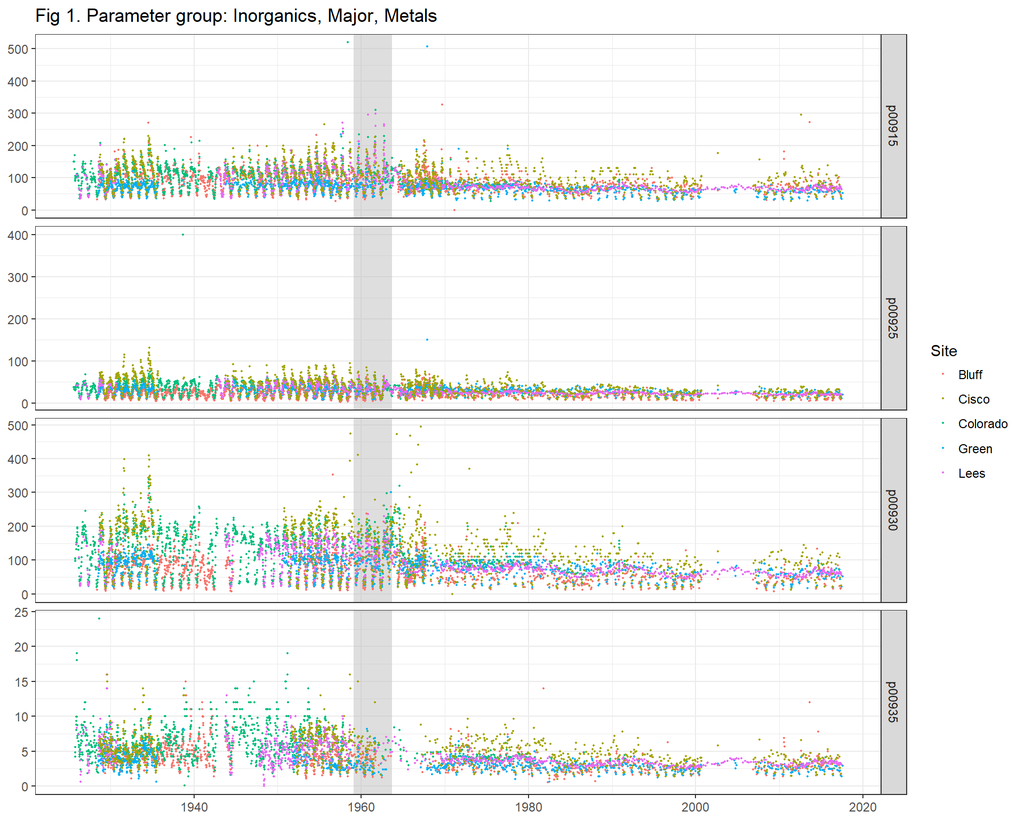

### Inorganic, Major, Non-metals

Seven parameters fall under the *Inorganics, Major, Non-metals* group. Figure 2 shows measurements taken for each parameter across all sites. Several of the parameters have an observable cyclical periodicity as observed with the *Inorganics, Major, Metals* group prior to dam construction. Post-dam construction that pattern attenuates over time.

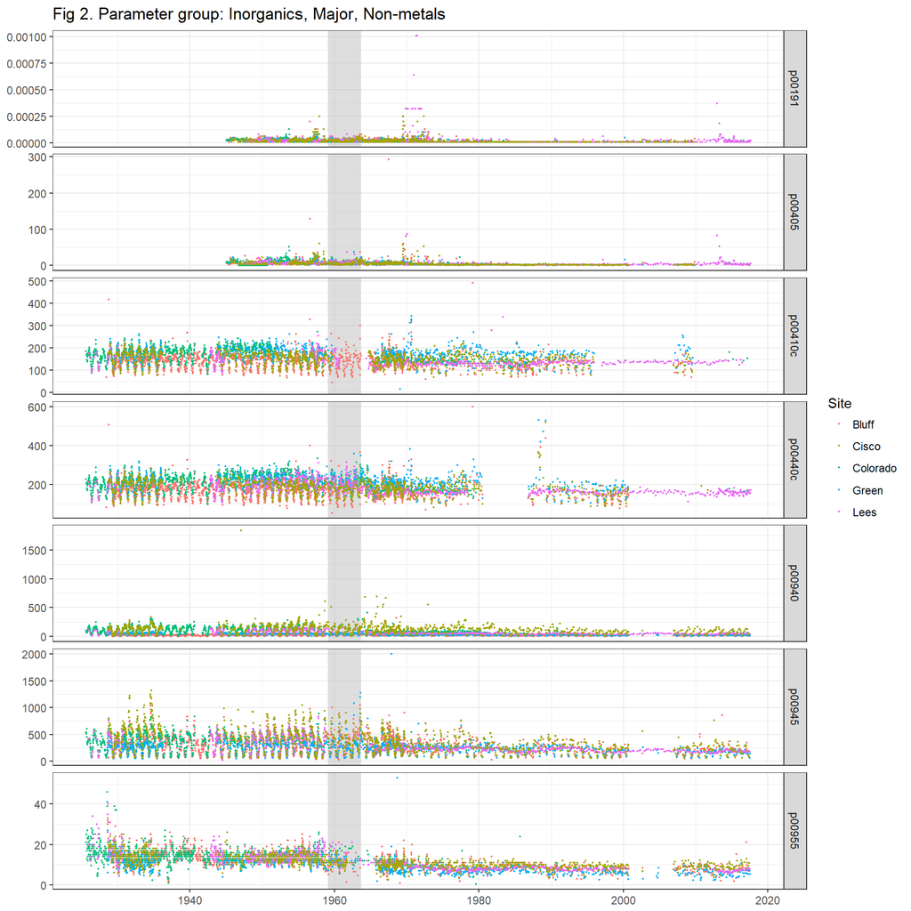

### Inorganic, Minor, Metals & Sediment

One parameter falls under each of the *Inorganics, Minor, Metals* and *Sediment* groups. Data seems to be incomplete for Iron concentration (p01046) across all sites, and range of values for suspended sediment concentration (p80145) varies across sites (Fig. 3).

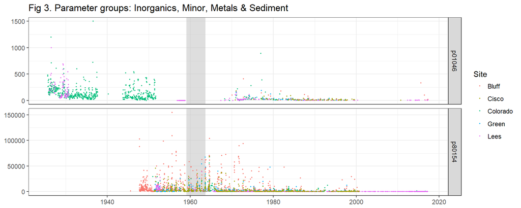

### Nutrient

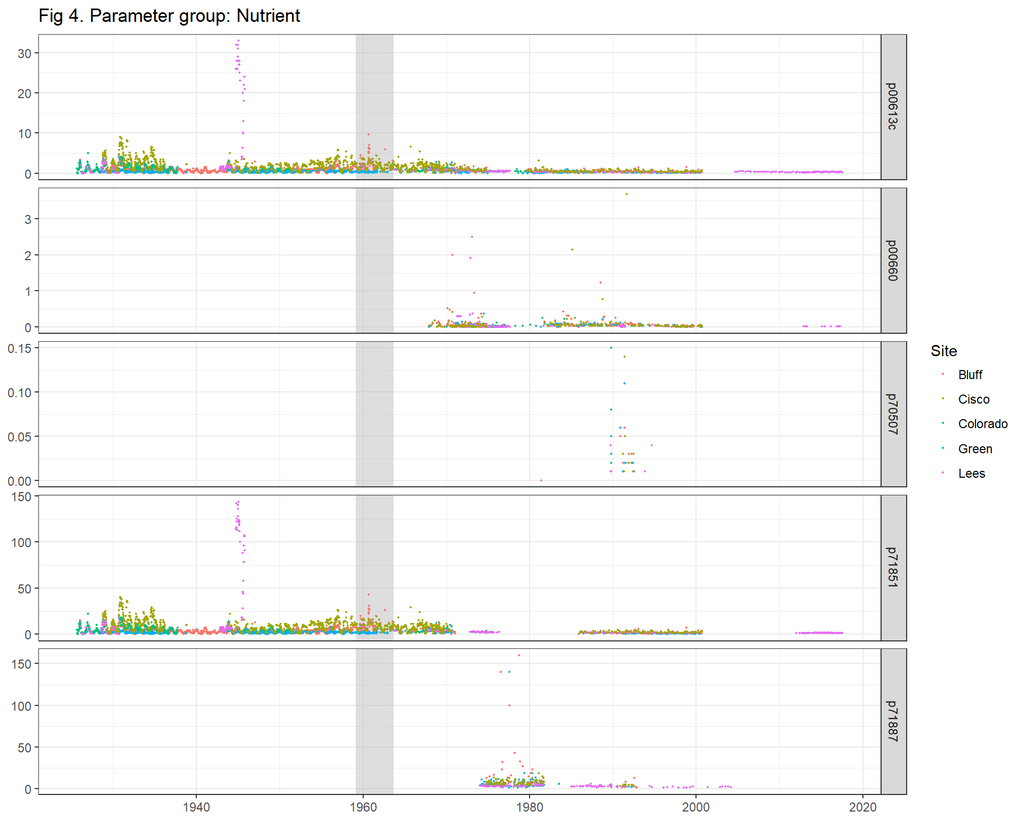

### Physical

Six parameters fall under the *Physical* group. Several physical parameters exhibit similar observable patterns as other parameters where prior to dam construction there is a discernable periodicity and then post dam construction there is an attenuated pattern (Fig. 5). Unlike other physical parameters, pH levels show a trend of increasing levels over time.

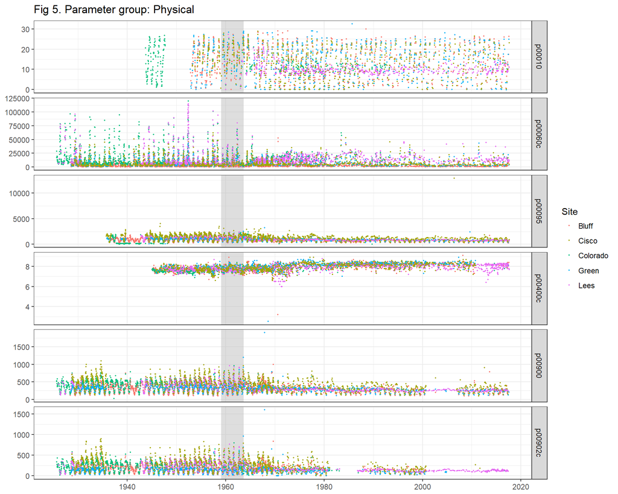

### Among group comparisons pre- and post-dam construction

#### Nitrate measured by nitrogen (p00613c)

Pre-dam, all sites were significantly different in nitrate concention with the exception of Lees Ferry and Colorado. Post-dam, Lees Ferry and Colorado were significantly different, but Lees Ferry and Bluff had similar nitrate concentrations.

Pre-dam:

```
##   Kruskal-Wallis rank sum test
##
## data: x and group
## Kruskal-Wallis chi-squared = 1590.5962, df = 4, p-value = 0
##
##
##                            Comparison of x by group
##                                  (Bonferroni)
## Col Mean-|
## Row Mean |      Bluff      Cisco   Colorado      Green
## ---------+--------------------------------------------
##    Cisco |  -30.42920
##          |     0.0000
## Colorado |  -6.223764   19.41813
##          |     0.0000     0.0000
##    Green |   13.79709   36.97343   17.09723
##          |     0.0000     0.0000     0.0000
##     Lees |  -7.116047   11.50511  -2.524858  -15.60141
##          |     0.0000     0.0000     0.0579     0.0000
```

Post-dam:

```
##   Kruskal-Wallis rank sum test
##
## data: x and group
## Kruskal-Wallis chi-squared = 314.5261, df = 4, p-value = 0
##
##
##                            Comparison of x by group
##                                  (Bonferroni)
## Col Mean-|
## Row Mean |      Bluff      Cisco   Colorado      Green
## ---------+--------------------------------------------
##    Cisco |  -9.418311
##          |     0.0000
## Colorado |  -6.005590   0.696727
##          |     0.0000     1.0000
##    Green |   7.439934   16.67320   11.46358
##          |     0.0000     0.0000     0.0000
##     Lees |  -1.974264   8.919655   5.095276  -10.30934
##          |     0.2418     0.0000     0.0000     0.0000
```

#### pH (p00400c)

Pre-dam:

```
##   Kruskal-Wallis rank sum test
##
## data: x and group
## Kruskal-Wallis chi-squared = 102.6063, df = 4, p-value = 0
##
##
##                            Comparison of x by group
##                                  (Bonferroni)
## Col Mean-|
## Row Mean |      Bluff      Cisco   Colorado      Green
## ---------+--------------------------------------------
##    Cisco |  -2.328738
##          |     0.0994
## Colorado |   2.305546   4.283227
##          |     0.1057     0.0001
##    Green |  -7.922164  -5.463126  -9.313858
##          |     0.0000     0.0000     0.0000
##     Lees |   0.376165   2.465238  -1.759748   7.611136
##          |     1.0000     0.0685     0.3923     0.0000
```

Post-dam:

```
##   Kruskal-Wallis rank sum test
##
## data: x and group
## Kruskal-Wallis chi-squared = 377.9837, df = 4, p-value = 0
##
##
##                            Comparison of x by group
##                                  (Bonferroni)
## Col Mean-|
## Row Mean |      Bluff      Cisco   Colorado      Green
## ---------+--------------------------------------------
##    Cisco |  -2.054670
##          |     0.1996
## Colorado |   1.815543   3.102216
##          |     0.3472     0.0096
##    Green |  -7.701332  -5.548586  -6.687094
##          |     0.0000     0.0000     0.0000
##     Lees |   11.13360   12.99779   5.053670   18.70063
##          |     0.0000     0.0000     0.0000     0.0000
```

#### Calcium

Pre-dam:

```
##   Kruskal-Wallis rank sum test
##
## data: x and group
## Kruskal-Wallis chi-squared = 854.6075, df = 4, p-value = 0
##
##
##                            Comparison of x by group
##                                  (Bonferroni)
## Col Mean-|
## Row Mean |      Bluff      Cisco   Colorado      Green
## ---------+--------------------------------------------
##    Cisco |  -12.83400
##          |     0.0000
## Colorado |  -7.400764   5.209877
##          |     0.0000     0.0000
##    Green |   18.82755   27.53720   23.39841
##          |     0.0000     0.0000     0.0000
##     Lees |  -1.646013   8.839756   4.340258  -16.88316
##          |     0.4988     0.0000     0.0001     0.0000
```

Post-dam:

```
##   Kruskal-Wallis rank sum test
##
## data: x and group
## Kruskal-Wallis chi-squared = 228.6106, df = 4, p-value = 0
##
##
##                            Comparison of x by group
##                                  (Bonferroni)
## Col Mean-|
## Row Mean |      Bluff      Cisco   Colorado      Green
## ---------+--------------------------------------------
##    Cisco |  -6.641662
##          |     0.0000
## Colorado |  -2.019840   2.357447
##          |     0.2170     0.0920
##    Green |   8.319678   14.83800   7.484273
##          |     0.0000     0.0000     0.0000
##     Lees |   0.994060   7.640860   2.671649  -7.350924
##          |     1.0000     0.0000     0.0377     0.0000
```

#### Magnesium (p00925)

Pre-dam, all sites exhibited signicantly different magnesium concentrations. Post-dam, Cisco showed similar concentration levels as Colorado and Green, and Green was similar to Colorado.

Pre-dam:

```
##   Kruskal-Wallis rank sum test
##
## data: x and group
## Kruskal-Wallis chi-squared = 1252.3646, df = 4, p-value = 0
##
##
##                            Comparison of x by group
##                                  (Bonferroni)
## Col Mean-|
## Row Mean |      Bluff      Cisco   Colorado      Green
## ---------+--------------------------------------------
##    Cisco |  -33.72352
##          |     0.0000
## Colorado |  -21.87273   11.59486
##          |     0.0000     0.0000
##    Green |  -12.26428   17.33254   6.835807
##          |     0.0000     0.0000     0.0000
##     Lees |  -15.56975   13.11515   2.926075  -3.383352
##          |     0.0000     0.0000     0.0172     0.0036
```

Post-dam:

```
##   Kruskal-Wallis rank sum test
##
## data: x and group
## Kruskal-Wallis chi-squared = 265.5488, df = 4, p-value = 0
##
##
##                            Comparison of x by group
##                                  (Bonferroni)
## Col Mean-|
## Row Mean |      Bluff      Cisco   Colorado      Green
## ---------+--------------------------------------------
##    Cisco |  -13.83901
##          |     0.0000
## Colorado |  -9.245350  -0.098739
##          |     0.0000     1.0000
##    Green |  -13.58489   0.272283   0.279550
##          |     0.0000     1.0000     1.0000
##     Lees |  -8.828083   5.123495   3.481389   4.855784
##          |     0.0000     0.0000     0.0025     0.0000
```

#### Bicarbonate (p00440c)

Similar to magnesium, bicarbonate concentrations were different across all sites pre-dam. Post-dam, Bluff and Lees Ferry were similar as were Cisco and Colorado, and Green and Colorado.

Pre-dam:

```
##   Kruskal-Wallis rank sum test
##
## data: x and group
## Kruskal-Wallis chi-squared = 1186.8545, df = 4, p-value = 0
##
##
##                            Comparison of x by group
##                                  (Bonferroni)
## Col Mean-|
## Row Mean |      Bluff      Cisco   Colorado      Green
## ---------+--------------------------------------------
##    Cisco |  -8.018303
##          |     0.0000
## Colorado |  -30.46365  -19.56156
##          |     0.0000     0.0000
##    Green |  -23.94859  -14.79653   3.386981
##          |     0.0000     0.0000     0.0035
##     Lees |  -10.34087  -3.002199   14.49687   10.59371
##          |     0.0000     0.0134     0.0000     0.0000
```

Post-dam:

```
##   Kruskal-Wallis rank sum test
##
## data: x and group
## Kruskal-Wallis chi-squared = 90.2544, df = 4, p-value = 0
##
##
##                            Comparison of x by group
##                                  (Bonferroni)
## Col Mean-|
## Row Mean |      Bluff      Cisco   Colorado      Green
## ---------+--------------------------------------------
##    Cisco |  -4.610606
##          |     0.0000
## Colorado |  -5.116702  -1.600310
##          |     0.0000     0.5476
##    Green |  -8.369309  -3.897106  -1.355385
##          |     0.0000     0.0005     0.8765
##     Lees |  -2.372934   2.872445   3.772298   7.237603
##          |     0.0882     0.0204     0.0008     0.0000
```